# Evaluaciones Certificado Design Thinking - Ed #5

Ramiro Casó - Incae Business School

6/28/2021

# Intro

El presente documento es un reporte que integra las evaluaciones realizadas por los participantes de la 5ta edición del Certificado de Design Thinking.

Para la elaboración de reporte se procedió a exportar la data de la plataforma Canvas, limpiar y re-ordenarla, eliminando columnas sin información y acomodando los títulos para que se leyeran con claridad.

Adicionalmente, se crearon 4 variables nuevas.

1. **Semana:** identificación de la semana evaluada.
2. **Edición:** identificación de la edición evaluada. Esta columna servirá para integrar más adelante las evaluaciones de todos los certificados.
3. **Efectividad Módulo Numérica:** Transformación a nivel de medida de intervalo de la variable “qué tan efectivo fue el módulo”, en donde 5 indica “muy efectivo” y 1 indica “muy inefectivo”.
4. **Efectividad AA/Webinar Numerica:** Transformación a nivel de medida de intervalo de la variable “efectividad del Office Hour o Webinar”, en donde 5 indica “muy efectivo” y 1 indica “muy inefectivo”

## Estadístícos descriptivos.

En la tabla que sigue se presentan los promedios y las deviaciones estándar para las evaluaciones del módulo y de las asesorías académicas / webinars.

Promedio y desviación de evaluaciones, por semana

| Semana | efectividad modulo | efectividad AA/Webinar | SD modulo | SD AA/Webinar |
| --- | --- | --- | --- | --- |
| 1 | 4.307692 | 4.000000 | 0.7510676 | 1.2247449 |
| 2 | 4.538462 | 4.153846 | 0.6602253 | 1.0681880 |
| 3 | 4.357143 | 4.083333 | 0.7449463 | 1.0836247 |
| 4 | 4.545454 | 4.416667 | 0.5222330 | 0.6685579 |

## Gráficas

Por último, presentamos dos sencillos gráficos de línea que representan cómo ha prograsado la evaluación promedio por semana a lo largo del curso. Este gráfico es importante porque permite ver si el performance ha mejorado o no.

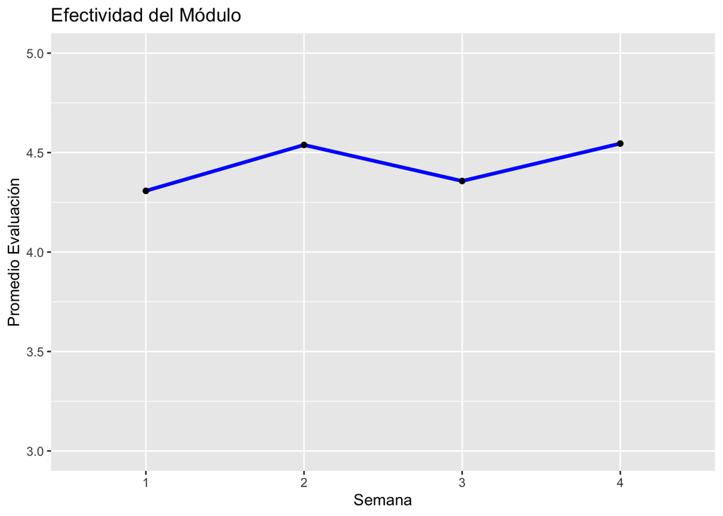

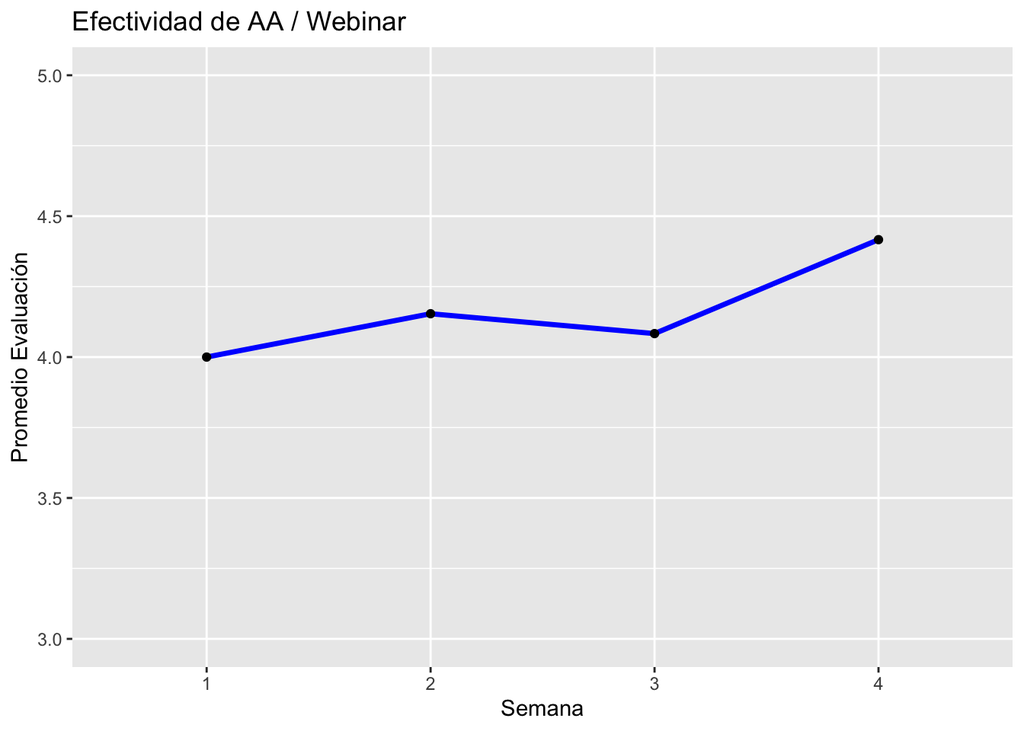